# LAB1

LAB 1 - Ella Haynes, Lab Partner: Lara Aygen Dodd

```python
import numpy as np
import matplotlib
import matplotlib.pyplot as plt
import scipy
from scipy import stats
```

QUESTION 1

```python
# integrating - this matches with the z table value of 0.37828
stats.norm.cdf(x = -0.31, loc = 0, scale = 1)
```

```
np.float64(0.3782804781779807)
```

```python
# integrating - this matches with the z table value of 0.99534
stats.norm.cdf(x = 2.6, loc = 0, scale = 1)
```

```
np.float64(0.9953388119762813)
```

```python
# integrating - this matches with the z table value of 0.68082
stats.norm.cdf(x = 0.47, loc = 0, scale = 1)
```

```
np.float64(0.6808224912174442)
```

```python
# doing the inverse: probability -> sigma
# this matches the expected value of ~0.47, per the z table
stats.norm.ppf(0.68, loc = 0, scale = 1)
```

```
np.float64(0.4676987991145084)
```

```python
# doing the inverse: probability -> sigma
# this matches the expected value of ~1.65, per the z table
stats.norm.ppf(0.95, loc = 0, scale = 1)
```

```
np.float64(1.6448536269514722)
```

```python
# doing the inverse: probability -> sigma
# this matches the expected value of ~2.33, per the z table
stats.norm.ppf(0.99, loc = 0, scale = 1)
```

```
np.float64(2.3263478740408408)
```

A negative sign did not appear, but, according to the table, that would mean there is a probability of 50% or less.

QUESTION 2

```python
# generate exponential distribution
exp_dist = stats.expon.rvs(loc = 0, scale = 1, size = 100000)
```

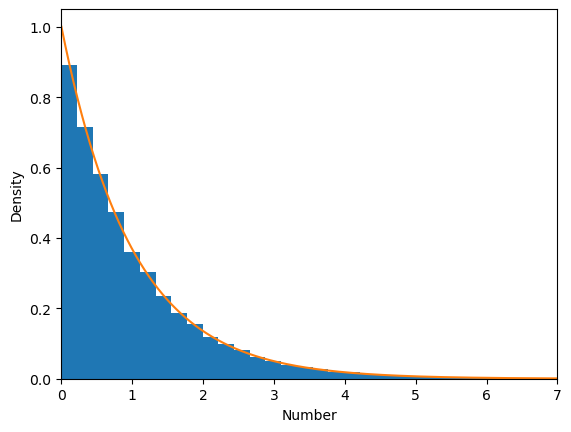

```python
# plot exponential distribution
fig, ax = plt.subplots(1, 1)
ax.hist(exp_dist, 50, density = True)
x = np.linspace(0, 7, 10000)
ax.plot(x, stats.expon.pdf(x, loc = 0, scale = 1))
plt.xlim([0, 7])
plt.xlabel("Number")
plt.ylabel("Density")
plt.show()
```

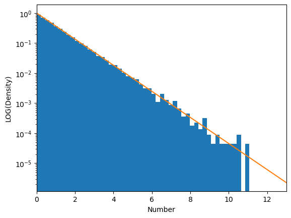

```python
# semilog (y) plot exponential distribution
fig, ax = plt.subplots(1, 1)
ax.hist(exp_dist, 50, density = True)
plt.yscale('log')
x = np.linspace(0, 13, 10000)
ax.plot(x, stats.expon.pdf(x, loc = 0, scale = 1))
plt.xlim([0, 13])
plt.xlabel("Number")
plt.ylabel("LOG(Density)")
plt.show()
```

QUESTION 3

My Statistical Question:

Given that my signal-free data follows an exponential distribution, what is the probability of a given data point being equivalent to or below a value of 3?

```python
# calculating the probability the background produced the signal
stats.expon.cdf(x = 3, loc = 0, scale = 1)
```

```
np.float64(0.950212931632136)
```

```python
# converting probability into an equivalent sigma
stats.expon.ppf(0.950212931632136)
```

```
np.float64(3.0)
```

```python
# selecting a value of 0.01:
stats.expon.cdf(x = 0.01, loc = 0, scale = 1)
```

```
np.float64(0.009950166250831945)
```

```python
# selecting a value of 0.01:
stats.expon.ppf(0.009950166250831945)
```

```
np.float64(0.009999999999999998)
```

```python
#selecting a value of 8:
stats.expon.cdf(x = 8, loc = 0, scale = 1)
```

```
np.float64(0.9996645373720975)
```

```python
# selecting a value of 8:
stats.expon.ppf(0.9996645373720975)
```

```
np.float64(7.999999999999987)
```

The most notable pattern I observed was that as the value increases, the probability increases. This makes sense because, looking at the plot of the exponential distribution, as the value increases along the x axis, more of the distribution is encompassed by the "less than or equivalent to" characteristic of the statistical question. Though expected due to the nature of the graph, it is still interesting to see how rapidly the distribution is encompassed with each increasing value in the lower numbers (for example the gap in probability between 0.01 - 3 is much larger than that of 3 - 8, despite the smaller numerical gap).